# **Time Series Analysis - Task 2**

Sofía Gianelli and Roberto Álvarez

## Dataset Import and Libraries

```python
from google.colab import drive
drive.mount('/content/drive')
```

```python
from google.colab import files
uploaded = files.upload()
```

Upload widget is only available when the cell has been executed in the current browser session. Please rerun this cell to enable.

```
Saving air traffic.xlsx to air traffic.xlsx
```

```python
!pip install pmdarima
```

```python
import pandas as pd
import numpy as np
df = pd.read_excel('air traffic.xlsx')
from statsmodels.tsa.seasonal import seasonal_decompose
from statsmodels.tsa.holtwinters import ExponentialSmoothing
import matplotlib.pyplot as plt
import seaborn as sns
from keras.models import Sequential
from keras.layers import LSTM, Dense
from sklearn.preprocessing import MinMaxScaler
from sklearn.metrics import mean_squared_error
import matplotlib.pyplot as plt
import statsmodels.api as sm
from scipy.signal import periodogram
from sklearn.metrics import mean_absolute_error
from statsmodels.tsa.stattools import adfuller
from statsmodels.tsa.seasonal import seasonal_decompose
from statsmodels.graphics.tsaplots import plot_acf, plot_pacf
from statsmodels.tsa.arima.model import ARIMA
from pmdarima.arima import auto_arima
from statsmodels.tsa.statespace.sarimax import SARIMAX
```

## Our Project

In our second task, we focused on analyzing flight data using ARIMA models. We began by preparing the data and visualizing the original flight series. After applying a natural logarithm transformation to stabilize the variance, we proceeded with the ARIMA modeling process. By examining the autocorrelation function (ACF) and partial autocorrelation function (PACF) plots, we determined the optimal orders for the ARIMA model. We justified our model selection based on metrics like Mean Squared Error (MSE) and Akaike Information Criterion (AIC), ensuring the chosen model's effectiveness. Additionally, we explained the behavior of ACF and PACF diagrams to support our model selection. Utilizing a bootstrap method, we evaluated estimates and confidence intervals, enhancing the reliability of our analysis. Finally, we forecasted future observations and assessed the forecast accuracy, providing valuable insights into flight traffic patterns for informed decision-making in airline operations and airport management.

## Data split 80%-20%

```python
# Convert object-type columns to numeric format
for col in df.columns:
    if df[col].dtype == 'object':
        df[col] = pd.to_numeric(df[col].str.replace(',', ''), errors='coerce')

# Combine 'Year' and 'Month' columns to create a new 'Date' column
df['Date'] = pd.to_datetime(df[['Year', 'Month']].astype(str).agg('-'.join, axis=1))

# Set the 'Date' column as the index
df.set_index("Date", inplace=True)

# Set the frequency of the index
df.index.freq = 'MS'  # 'MS' stands for Month Start

# Optionally, you can drop the 'Year' and 'Month' columns if they are no longer needed
df.drop(columns=['Year', 'Month'], inplace=True)

# Calculate the index to split the data (80% for training, 20% for testing)
split_index = int(len(df) * 0.80)

# Split the data into training (80%) and testing (20%) sets
train_data = df.iloc[:split_index]
test_data = df.iloc[split_index:]

# Display the shapes of the training and testing sets
print("Training data shape:", train_data.shape)
print("Testing data shape:", test_data.shape)
```

```
Training data shape: (163, 15)
Testing data shape: (41, 15)
```

# **Complete ARIMA Analysis:**

**Plot the original series**

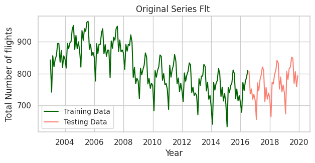

```python
# Set the style
sns.set(style="whitegrid")

# Create the plot
plt.figure(figsize=(7, 3))
sns.lineplot(data=train_data, x=train_data.index, y="Flt", color="darkgreen", label="Training Data")
sns.lineplot(data=test_data, x=test_data.index, y="Flt", color="salmon", label="Testing Data")

# Set labels and title
plt.xlabel("Year")
plt.ylabel("Total Number of flights")
plt.title("Original Series Flt ")

# Set legend
plt.legend(loc='lower left', fontsize='small')

# Show plot
plt.show()
```

The original series represents the total number of flights over time, spanning from 2003 to 2019. The data is organized monthly, with each data point indicating the total number of flights recorded for that specific month. The series has been split into training and testing datasets to facilitate the development and evaluation of predictive models. The training data is used to train the models, while the testing data serves to assess their performance and generalization ability. This splitting ensures that the models are trained on historical data and tested on unseen future data, mimicking real-world scenarios. We can see that since the year 2008 there is a clear lower trend in the number of flights that seems to pick it up from 2016 onwards.

```python
  # Taking the natural logarithm of the 'Flt' column in train_data
train_data['Flt'] = np.log(train_data['Flt'])

# Taking the natural logarithm of the 'Flt' column in test_data
test_data['Flt'] = np.log(test_data['Flt'])
```

To stabilize variance and achieve a more stationary time series, a natural logarithm transformation is applied to the original series.

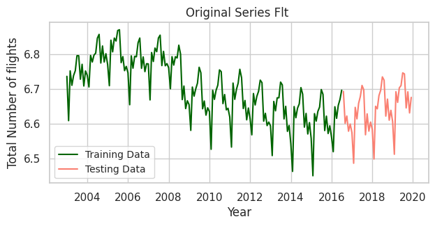

```python
# Create the plot
plt.figure(figsize=(7, 3))
sns.lineplot(data=train_data, x=train_data.index, y="Flt", color="darkgreen", label="Training Data")
sns.lineplot(data=test_data, x=test_data.index, y="Flt", color="salmon", label="Testing Data")

# Set labels and title
plt.xlabel("Year")
plt.ylabel("Total Number of flights")
plt.title("Original Series Flt ")

# Set legend
plt.legend(loc='lower left', fontsize='small')

# Show plot
plt.show()
```

## Dicky Fuller Test

In our analysis, we conducted the Dickey-Fuller test to assess the stationarity of the flight data series. The test is essential for determining whether the series exhibits a unit root, indicating non-stationarity, or if it is stationary, with constant statistical properties over time. Our initial test yielded an ADF statistic of -1.392018 and a p-value of 0.586097, indicating non-rejection of the null hypothesis of non-stationarity. Consequently, we applied first-order differencing to the series, resulting in a second Dickey-Fuller test with an ADF statistic of -2.802361 and a p-value of 0.057937, still failing to reject the null hypothesis. Subsequently, we performed second-order differencing, leading to a significant ADF statistic of -14.869118 and a p-value of 0.000000, prompting rejection of the null hypothesis, confirming the stationarity of the series. However, upon inspecting the autocorrelation and partial autocorrelation plots, we observed unusual patterns that prompted a reconsideration of our approach.

```python
result = adfuller(train_data['Flt'])
print('ADF Statistic: %f' % result[0])
print('p-value: %f' % result[1])
print('Critical Values:')
for key, value in result[4].items():
  print('\t%s: %.3f' % (key, value))
```

```
ADF Statistic: -1.392018
p-value: 0.586097
Critical Values:
	1%: -3.475
	5%: -2.881
	10%: -2.577
```

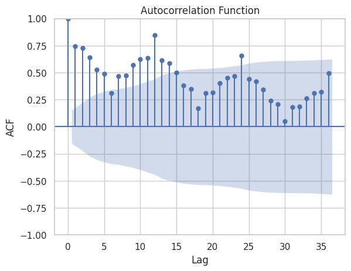

```python
plot_acf(train_data['Flt'], lags=36)
plt.title('Autocorrelation Function')
plt.xlabel('Lag')
plt.ylabel('ACF')
plt.show()
```

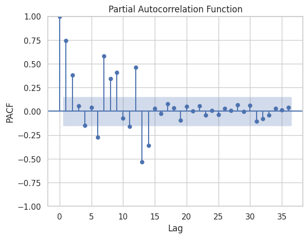

```python
  plot_pacf(train_data['Flt'], lags=36, method='ywm')
  plt.title('Partial Autocorrelation Function')
  plt.xlabel('Lag')
  plt.ylabel('PACF')
  plt.show()
```

El coeficiente de autocorrelación parcial de orden k muestra la correlación existente entre Yt y Yt−k una vez que se depura la dependencia lineal debida a valores intermedios, lo que podríamos llamar efectos indirectos a través de Yt−k+1 a Yt−1

## Diference

### Regular Difference

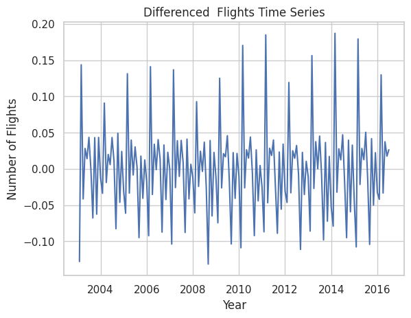

```python
flt_diff = train_data['Flt'].diff().dropna()
plt.plot(flt_diff)
plt.xlabel('Year')
plt.ylabel('Number of Flights')
plt.title('Differenced  Flights Time Series')
plt.show()
```

Dickey Fuller post diference

```python
result2 = adfuller(flt_diff)
print('ADF Statistic: %f' % result2[0])
print('p-value: %f' % result2[1])
print('Critical Values:')
for key, value in result2[4].items():
  print('\t%s: %.3f' % (key, value))
```

```
ADF Statistic: -2.802361
p-value: 0.057937
Critical Values:
	1%: -3.475
	5%: -2.881
	10%: -2.577
```

We don't reject H0 so the serie is still not stationary

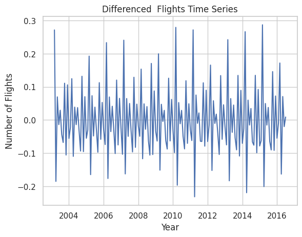

```python
flt_diff2 = flt_diff.diff().dropna()
plt.plot(flt_diff2)
plt.xlabel('Year')
plt.ylabel('Number of Flights')
plt.title('Differenced  Flights Time Series')
plt.show()
```

```python
result3 = adfuller(flt_diff2)
print('ADF Statistic: %f' % result3[0])
print('p-value: %f' % result3[1])
print('Critical Values:')
for key, value in result3[4].items():
  print('\t%s: %.3f' % (key, value))
```

```
ADF Statistic: -14.869118
p-value: 0.000000
Critical Values:
	1%: -3.475
	5%: -2.881
	10%: -2.577
```

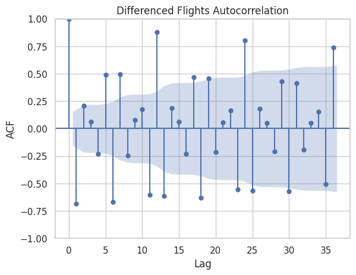

```python
plot_acf(flt_diff2, lags=36)
plt.title('Differenced Flights Autocorrelation')
plt.xlabel('Lag')
plt.ylabel('ACF')
plt.show()
```

There exists peaks every 12 months therefore we should apply the seasonal difference with 12

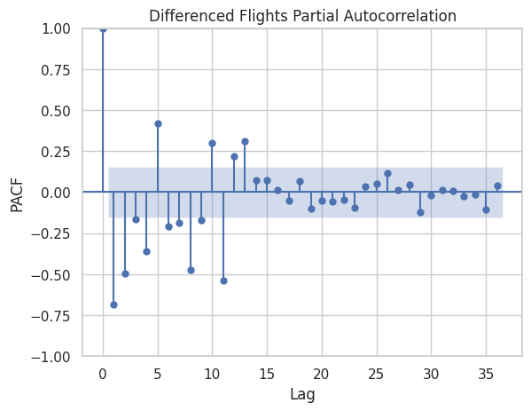

```python
plot_pacf(flt_diff2, lags=36, method='ywm')
plt.title('Differenced Flights Partial Autocorrelation')
plt.xlabel('Lag')
plt.ylabel('PACF')
plt.show()
```

### Seasonal Difference

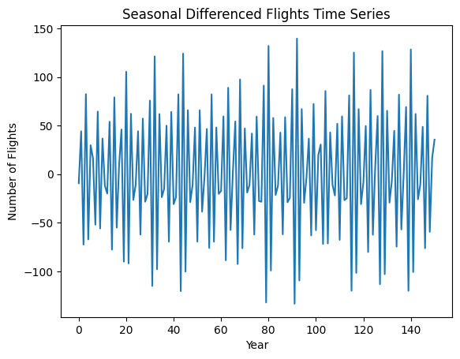

```python
# Difference the resulting series again with a lag of 12
flt_diffa12 = np.diff(train_data['Flt'], 12)

# Plot the differenced series
plt.plot(flt_diffa12)
plt.xlabel('Year')
plt.ylabel('Number of Flights')
plt.title('Seasonal Differenced Flights Time Series')
plt.show()
```

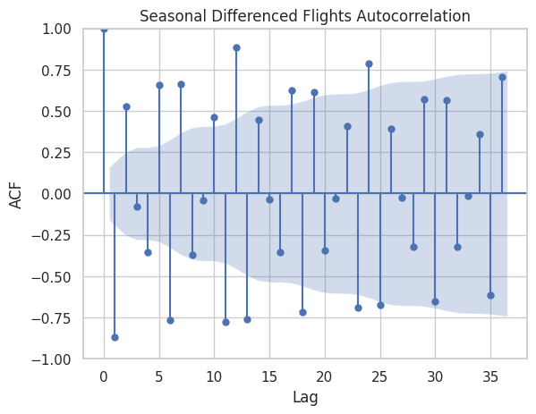

```python
plot_acf(flt_diffa12, lags=36)
plt.title('Seasonal Differenced Flights Autocorrelation')
plt.xlabel('Lag')
plt.ylabel('ACF')
plt.show()
```

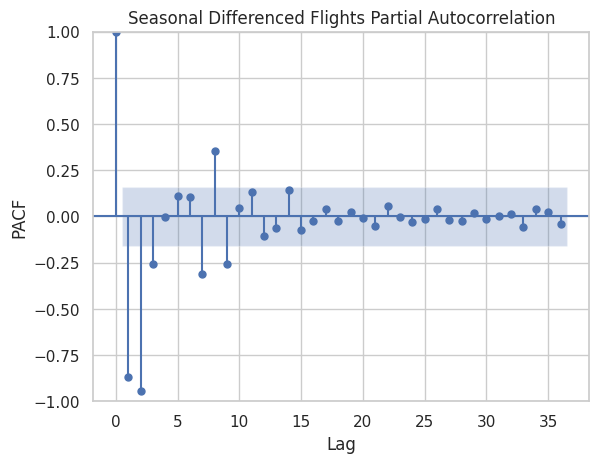

```python
plot_pacf(flt_diffa12, lags=36, method='ywm')
plt.title('Seasonal Differenced Flights Partial Autocorrelation')
plt.xlabel('Lag')
plt.ylabel('PACF')
plt.show()
```

```python
result4 = adfuller(flt_diffa12)
print('ADF Statistic: %f' % result4[0])
print('p-value: %f' % result4[1])
print('Critical Values:')
for key, value in result4[4].items():
  print('\t%s: %.3f' % (key, value))
```

```
ADF Statistic: -16.451014
p-value: 0.000000
Critical Values:
	1%: -3.479
	5%: -2.883
	10%: -2.578
```

## Modelling

We already investigated the stationary condition of the serie, but we need to train a model to obtain the forecast of the next months.

The first step of this part is to find the model with the lowest AIC. The AIC serves as a measure of the model's goodness of fit while penalizing for the number of parameters involved, making it a valuable metric for model selection. In order to obtain this model we created a loop that iterates through various combinations of parameters for fitting SARIMA models to the training data. The parameter ranges cover various combinations of autoregressive, differencing, and moving average components for both the non-seasonal and seasonal parts of the SARIMA model. We decide to set up the ranges in (0,3) which is the recommended. After iterating through all combinations, the results are sorted based on the AIC values in ascending order.

```python
import warnings
warnings.filterwarnings("ignore")

# Define range of parameters to try
p_values = range(0, 3)  # AR order
d_values = range(0, 2)   # I order (list containing a single value)
q_values = range(0, 3)  # MA order
P_values = range(0, 3)  # Seasonal AR order
D_values = range(0, 2)   # Seasonal I order (list containing a single value)
Q_values = range(0, 3)  # Seasonal MA order

# Initialize DataFrame to store AIC values
results = pd.DataFrame(columns=['Order', 'Seasonal_Order', 'AIC'])

# Loop through all combinations
for p in p_values:
    for d in d_values:
        for q in q_values:
            for P in P_values:
                for D in D_values:
                    for Q in Q_values:
                        order = (p, d, q)
                        seasonal_order = (P, D, Q, 12)  # Assuming monthly seasonality

                        # Fit SARIMA model
                        model = SARIMAX(train_data['Flt'], order=order, seasonal_order=seasonal_order)
                        fitted_model = model.fit()

                        # Store AIC value in DataFrame
                        results = results.append({'Order': order, 'Seasonal_Order': seasonal_order, 'AIC': fitted_model.aic}, ignore_index=True)

# Sort results by AIC (lower is better)
results = results.sort_values(by='AIC')

# Print top models
print("Top models based on AIC:")
print(results.head())
```

```
Top models based on AIC:
         Order Seasonal_Order         AIC
169  (1, 1, 0)  (1, 0, 1, 12) -831.675835
79   (0, 1, 1)  (1, 0, 1, 12) -831.027686
97   (0, 1, 2)  (1, 0, 1, 12) -830.325620
277  (2, 1, 0)  (1, 0, 1, 12) -830.150855
187  (1, 1, 1)  (1, 0, 1, 12) -830.059909
```

After having the five models with the lowest AIC, we decided to use the _"auto*arima"* function with higher range, to obtain the best possible model based on a broader search space. This model selection process aims to optimize the balance between model complexity and goodness of fit, ultimately resulting in a model that provides accurate forecasts while avoiding overfitting.

```python
# Assuming train is your time series data
model = auto_arima(train_data['Flt'],
                   seasonal=True,
                   start_p=0,
                   start_d=0,
                   start_q=0,
                   max_p=5,
                   max_d=2,
                   max_q=5,
                   start_P=0,
                   start_D=0,
                   start_Q=0,
                   max_P=5,
                   max_D=2,
                   max_Q=5,
                   m=12,
                   suppress_warnings=True,
                   stepwise=True)
# Print the selected model
print("Selected Model:")
print(model)

# Print the AIC
print("AIC:", model.aic())
```

```
Selected Model:
 ARIMA(2,0,0)(3,1,0)[12]
AIC: -820.9303697348164
```

In this part we will compare the model with the lowest AIC found it before, and the one what the function _"auto*arima"* gave us.

```python
model_auto = SARIMAX(train_data['Flt'], order=(2, 0, 0),seasonal_order = (3, 1, 0, 12))
model_auto_fit = model_auto.fit()

# Summary of the model
print(model_auto_fit.summary())
```

```
                                     SARIMAX Results
==========================================================================================
Dep. Variable:                                Flt   No. Observations:                  163
Model:             SARIMAX(2, 0, 0)x(3, 1, 0, 12)   Log Likelihood                 416.465
Date:                            Wed, 20 Mar 2024   AIC                           -820.930
Time:                                    17:14:52   BIC                           -802.827
Sample:                                01-01-2003   HQIC                          -813.576
                                     - 07-01-2016
Covariance Type:                              opg
==============================================================================
                 coef    std err          z      P>|z|      [0.025      0.975]
------------------------------------------------------------------------------
ar.L1          0.6852      0.081      8.451      0.000       0.526       0.844
ar.L2          0.2658      0.083      3.190      0.001       0.103       0.429
ar.S.L12      -0.6996      0.090     -7.773      0.000      -0.876      -0.523
ar.S.L24      -0.6991      0.069    -10.110      0.000      -0.835      -0.564
ar.S.L36      -0.3987      0.082     -4.847      0.000      -0.560      -0.237
sigma2         0.0002   1.76e-05     12.087      0.000       0.000       0.000
===================================================================================
Ljung-Box (L1) (Q):                   0.03   Jarque-Bera (JB):               147.09
Prob(Q):                              0.87   Prob(JB):                         0.00
Heteroskedasticity (H):               0.88   Skew:                             0.45
Prob(H) (two-sided):                  0.64   Kurtosis:                         7.75
===================================================================================

Warnings:
[1] Covariance matrix calculated using the outer product of gradients (complex-step).
```

```python
model_loop = SARIMAX(train_data['Flt'], order=(1, 1, 0),seasonal_order = (1, 0, 1, 12))
model_loop_fit = model_loop.fit()

# Summary of the model
print(model_loop_fit.summary())
```

```
                                      SARIMAX Results
============================================================================================
Dep. Variable:                                  Flt   No. Observations:                  163
Model:             SARIMAX(1, 1, 0)x(1, 0, [1], 12)   Log Likelihood                 419.838
Date:                              Wed, 20 Mar 2024   AIC                           -831.676
Time:                                      15:40:28   BIC                           -819.325
Sample:                                  01-01-2003   HQIC                          -826.661
                                       - 07-01-2016
Covariance Type:                                opg
==============================================================================
                 coef    std err          z      P>|z|      [0.025      0.975]
------------------------------------------------------------------------------
ar.L1         -0.3461      0.062     -5.616      0.000      -0.467      -0.225
ar.S.L12       0.9961      0.003    351.176      0.000       0.991       1.002
ma.S.L12      -0.7192      0.074     -9.665      0.000      -0.865      -0.573
sigma2         0.0003   2.01e-05     13.014      0.000       0.000       0.000
===================================================================================
Ljung-Box (L1) (Q):                   0.06   Jarque-Bera (JB):                49.77
Prob(Q):                              0.80   Prob(JB):                         0.00
Heteroskedasticity (H):               0.90   Skew:                             0.32
Prob(H) (two-sided):                  0.70   Kurtosis:                         5.64
===================================================================================

Warnings:
[1] Covariance matrix calculated using the outer product of gradients (complex-step).
```

```python
# Calculate AIC for Model 1
aic_model_auto = model_auto_fit.aic

# Calculate AIC for Model 2
aic_model_loop = model_loop_fit.aic

print("AIC for SARIMA(2, 0, 0)x(3, 1, 0, 12):", aic_model_auto)
print("AIC for SARIMA(1, 1, 0)x(1, 0, 1, 12):", aic_model_loop)
```

```
AIC for SARIMA(2, 0, 0)x(3, 1, 0, 12): -820.9303697348164
AIC for SARIMA(1, 1, 0)x(1, 0, 1, 12): -831.6758347332197
```

The AIC for SARIMA(1, 1, 0)x(1, 0, 1, 12) is smaller than for SARIMA(2, 0, 0)x(3, 1, 0, 12) but we will compare the RMSE because our objective is to forecast the serie.

# **Forecasting**

**Model SARIMA(2, 0, 0)x(3, 1, 0, 12)**

```python
# Predictions
predictions_auto = model_auto_fit.predict(start=len(train_data['Flt']),
                                end = len(train_data['Flt']) + len(test_data['Flt'])-1,
                                typ="levels")
df_result = pd.DataFrame({
    "Real test data": np.exp(test_data['Flt'].values),  # Converting to original scale if needed
    "Predicted Number of Flights": np.exp(predictions_auto)  # Converting to original scale if needed
})

print(df_result)
```

```
            Real test data  Predicted Number of Flights
2016-08-01         806.894                   806.098430
2016-09-01         735.933                   725.147183
2016-10-01         751.607                   749.748549
2016-11-01         719.350                   712.824054
2016-12-01         734.434                   724.658306
2017-01-01         716.411                   703.448791
2017-02-01         655.855                   655.722715
2017-03-01         770.634                   767.974497
2017-04-01         745.517                   745.209176
2017-05-01         779.642                   771.673855
2017-06-01         795.324                   778.992870
2017-07-01         820.949                   811.173962
2017-08-01         810.895                   803.154969
2017-09-01         712.042                   727.336487
2017-10-01         756.360                   754.578795
2017-11-01         719.555                   709.572960
2017-12-01         738.657                   725.295787
2018-01-01         723.111                   694.371309
2018-02-01         663.958                   637.935395
2018-03-01         773.066                   760.885177
2018-04-01         767.348                   739.773180
2018-05-01         797.342                   762.458809
2018-06-01         809.686                   771.532020
2018-07-01         841.499                   808.095955
2018-08-01         833.431                   796.413120
2018-09-01         751.454                   721.461649
2018-10-01         789.191                   750.575368
2018-11-01         742.649                   709.005568
2018-12-01         764.065                   728.066796
2019-01-01         739.803                   698.902739
2019-02-01         673.087                   644.563409
2019-03-01         806.233                   759.157172
2019-04-01         781.801                   738.970517
2019-05-01         815.270                   762.751915
2019-06-01         820.663                   773.502038
2019-07-01         851.326                   806.764477
2019-08-01         848.650                   797.787680
2019-09-01         769.351                   719.725833
2019-10-01         805.988                   748.084405
2019-11-01         758.402                   710.068183
2019-12-01         793.144                   725.800505
```

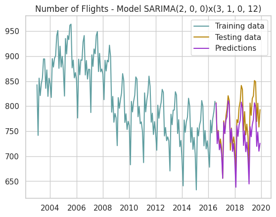

```python
plt.plot(train_data['Flt'].index, np.exp(train_data['Flt'].values),
         label='Training data',color="#5F9EA0")
plt.plot(test_data['Flt'].index, np.exp(test_data['Flt'].values),
         label='Testing data',color="#B8860B")
plt.plot(test_data['Flt'].index, np.exp(predictions_auto),
         label='Predictions',color="#9932CC")
plt.title('Number of Flights - Model SARIMA(2, 0, 0)x(3, 1, 0, 12)')
plt.legend()
plt.show()
```

**Model SARIMA(1, 1, 0)x(1, 0, 1, 12)**

```python
# Predictions
predictions_loop = model_loop_fit.predict(start=len(train_data['Flt']),
                                end = len(train_data['Flt']) + len(test_data['Flt'])-1,
                                typ="levels")
df_result2 = pd.DataFrame({
    "Real test data": np.exp(test_data['Flt'].values),  # Converting to original scale if needed
    "Predicted Number of Flights": np.exp(predictions_loop)  # Converting to original scale if needed
})

print(df_result2)
```

```
            Real test data  Predicted Number of Flights
2016-08-01         806.894                   804.599443
2016-09-01         735.933                   727.590119
2016-10-01         751.607                   753.701273
2016-11-01         719.350                   714.823499
2016-12-01         734.434                   730.536610
2017-01-01         716.411                   707.482436
2017-02-01         655.855                   657.569321
2017-03-01         770.634                   765.229060
2017-04-01         745.517                   742.858330
2017-05-01         779.642                   766.147120
2017-06-01         795.324                   775.450919
2017-07-01         820.949                   806.194907
2017-08-01         810.895                   797.574870
2017-09-01         712.042                   722.609607
2017-10-01         756.360                   748.048670
2017-11-01         719.555                   709.735951
2017-12-01         738.657                   725.230935
2018-01-01         723.111                   702.446316
2018-02-01         663.958                   653.067881
2018-03-01         773.066                   759.548227
2018-04-01         767.348                   737.427300
2018-05-01         797.342                   760.455507
2018-06-01         809.686                   769.654269
2018-07-01         841.499                   800.048470
2018-08-01         833.431                   791.526962
2018-09-01         751.454                   717.403257
2018-10-01         789.191                   742.559921
2018-11-01         742.649                   704.671215
2018-12-01         764.065                   719.995640
2019-01-01         739.803                   697.461375
2019-02-01         673.087                   648.615695
2019-03-01         806.233                   753.930732
2019-04-01         781.801                   732.056866
2019-05-01         815.270                   754.827827
2019-06-01         820.663                   763.923082
2019-07-01         851.326                   793.972324
2019-08-01         848.650                   785.547983
2019-09-01         769.351                   712.254283
2019-10-01         805.988                   737.132386
2019-11-01         758.402                   699.661950
2019-12-01         793.144                   714.818115
```

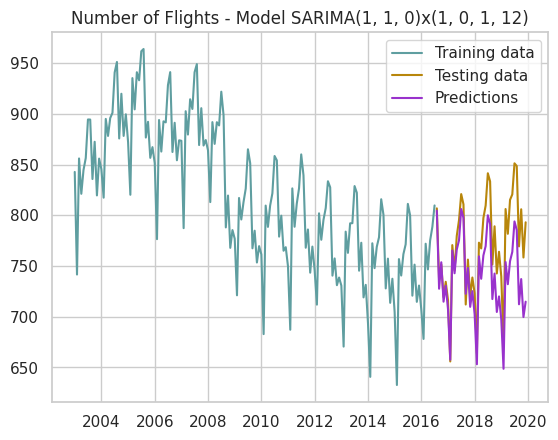

```python
plt.plot(train_data['Flt'].index, np.exp(train_data['Flt'].values),
         label='Training data',color="#5F9EA0")
plt.plot(test_data['Flt'].index, np.exp(test_data['Flt'].values),
         label='Testing data',color="#B8860B")
plt.plot(test_data['Flt'].index, np.exp(predictions_loop),
         label='Predictions',color="#9932CC")
plt.title('Number of Flights - Model SARIMA(1, 1, 0)x(1, 0, 1, 12)')
plt.legend()
plt.show()
```

```python
# Calculate RMSE for Model 1
rmse_model_auto = np.sqrt(mean_squared_error(np.exp(test_data['Flt'].values), np.exp(predictions_auto)))

# Calculate RMSE for Model 2
rmse_model_loop = np.sqrt(mean_squared_error(np.exp(test_data['Flt'].values), np.exp(predictions_loop)))

print("RMSE for SARIMA(2, 0, 0)x(3, 1, 0, 12):", rmse_model_auto)
print("RMSE for SARIMA(1, 1, 0)x(1, 0, 1, 12):", rmse_model_loop)
```

```
RMSE for SARIMA(2, 0, 0)x(3, 1, 0, 12): 32.2348461491676
RMSE for SARIMA(1, 1, 0)x(1, 0, 1, 12): 36.883057215181545
```

While the SARIMA(1, 1, 0)x(1, 0, 1, 12) model shows a lower AIC value compared to others, the model generated by the _"auto*arima"* function demonstrates the lowest Root Mean Squared Error (RMSE).

# **Bootstrap Method**

Block bootstrap is a resampling technique used for time series data where simple random sampling is not appropriate due to autocorrelation. It's particularly useful for preserving the temporal structure of the data.

We are going to make a block bootstrap procedure to estimate the uncertainty associated with the parameters of a SARIMA(2, 0, 0)x(3, 1, 0, 12) model.

```python
# Set seed for reproducibility
np.random.seed(1899)

# Define the length of the dataset and the observed data
n = len(train_data)
y = train_data["Flt"]

# Block bootstrap
blockLen = 10
blockNum = round(n / blockLen)
betaBlock = []

for _ in range(500):
    # Randomly select starting points for blocks
    start = np.random.choice(range(n - blockLen + 1), size=blockNum, replace=True)
    blockedIndices = np.concatenate([np.arange(s, s + blockLen) for s in start])
    eso = y[blockedIndices]  # Select the blocked data

    # Fit the SARIMAX(2,0,0)*(3,1,0,12) model to the blocked data
    model = SARIMAX(eso, order=(2, 0, 0), seasonal_order=(3, 1, 0, 12)) #this is the model with the lowest RMSE
    model_fit = model.fit(disp=False)

    # Store the estimated parameters
    betaBlock.append(model_fit.params[0])

# Convert to numpy array for easier manipulation
betaBlock = np.array(betaBlock)

# Calculate standard deviation and confidence intervals
std_betaBlock = np.std(betaBlock)
conf_intervals = np.quantile(betaBlock, [0.025, 0.975])

# Print results
print(f"Standard deviation: {std_betaBlock}")
print(f"95% Confidence Interval: {conf_intervals}")
```

```
Standard deviation: 0.06208328702920395
95% Confidence Interval: [0.4102948  0.65997905]
```

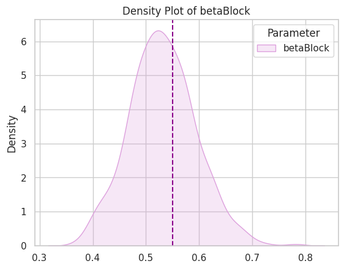

```python
# Set the style of the seaborn plot
sns.set(style="whitegrid")

# Plot the density of betaBlock with seaborn
sns.kdeplot(betaBlock, color="#DDA0DD", label="betaBlock", fill=True)

# Adding a vertical line at the value 0.5
plt.axvline(x=0.55, color="#8B008B", linestyle='--')

# Customizing the plot
plt.xlabel('')  # Empty x-axis label
plt.legend(title='Parameter', loc='upper right', labels=['betaBlock'])
plt.title('Density Plot of betaBlock')

# Show the plot
plt.show()
```